# Reproducible Research - Project 1

Note: the generated PA1_template.html file can be viewed at: https://yafangchen.github.io/05_RR_Project1_Sep2014

## Load and preprocess the data

First, I will read the data into R

```r
if(!file.exists("activity.csv")){
        unzip("activity.zip")
}
data <- read.csv("activity.csv")
```

## What is mean total number of steps taken per day?

Here is a histogram of the total number of steps taken each day:

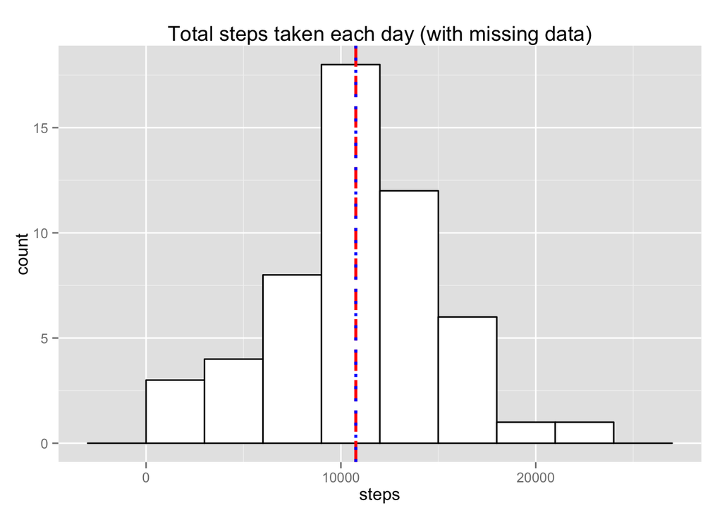

```r
options(scipen=999)
aggdata <- aggregate(steps~date,data,sum)
library(ggplot2)
t1 <- ggplot(aggdata,aes(x=steps))
t1 + geom_histogram(binwidth=3000,colour="black",fill="white") + geom_vline(aes(xintercept=mean(aggdata$steps)),color="red",linetype="longdash",size=1) + geom_vline(aes(xintercept=median(aggdata$steps)), color="blue",linetype="dotted",size=1) + ggtitle("Total steps taken each day (with missing data)")
```

The **mean** total number of steps taken per day is 10766.1887, while the **median** total number of steps taken per day is 10765.

## What is the average daily activity pattern?

To investigate the average daily activity pattern, a time series plot of the 5-minute interval (x-axis) and the average number of steps taken, averaged across all days (y-axis) is generated:

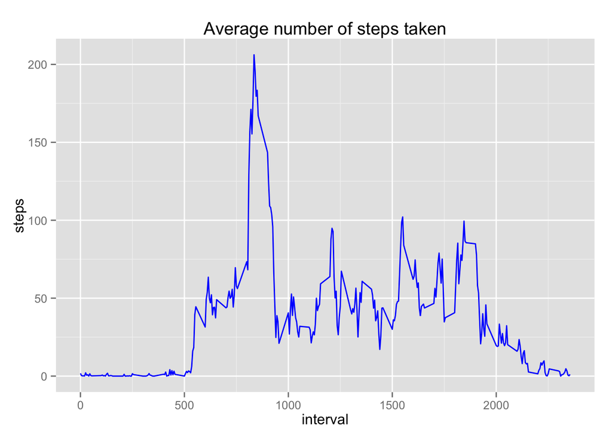

```r
aggdata2 <- aggregate(steps~interval,data,mean)
t2 <- ggplot(aggdata2,aes(x=interval,y=steps))
t2 + geom_line(colour="blue") + ggtitle("Average number of steps taken")
```

The 5-minute interval that contains the maximum number of steps is:

```r
aggdata2[(aggdata2$steps==max(aggdata2$steps)),]
```

```
##     interval steps
## 104      835 206.2
```

## Input missing values

Note that there are a number of days/intervals that have missing values (coded as NA). The total number of missing values in the dataset is:

```r
missing <- data[(data$steps=="NA"),]
nrow(missing)
```

```
## [1] 2304
```

To fill in the missing values, **the mean for that 5-minute interval** is used. And a new dataset (**mergedData**) with the missing data filled in is created:

```r
aggdata_mean <- aggregate(steps~interval,data,mean)
mergedData = merge(data,aggdata_mean,by="interval",all=TRUE)
mergedData[(is.na(mergedData$steps.x)),2] <- mergedData[(is.na(mergedData$steps.x)),4]
```

[figure not shown]

```r
aggmergedData <- aggregate(steps.x~date,mergedData,sum)
t3 <- ggplot(aggmergedData,aes(x=steps.x))
t1 + geom_histogram(binwidth=3000,colour="black",fill="white") + geom_vline(aes(xintercept=mean(aggmergedData$steps.x)),color="red",linetype="longdash",size=1) + geom_vline(aes(xintercept=median(aggmergedData$steps.x)), color="blue",linetype="dotted",size=1) + ggtitle("Total steps taken each day (no missing data)")
```

The **mean** total number of steps taken per day is 10766.1887, while the **median** total number of steps taken per day is 10766.1887.

Note that with the missing values filled in, the **mean** total number of steps taken per day is the same as before, but the **median** total number of steps taken per day is different.

## Are there differences in activity patterns between weekdays and weekends?

First, I create a new factor variable (**day**) in the dataset with two levels - “weekday” and “weekend” indicating whether a given date is a weekday or weekend.

```r
mergedData$date <- as.Date(mergedData$date)
mergedData$day <- ifelse((weekdays(mergedData[,c("date")],abbreviate=TRUE) %in% c("Mon","Tue","Wed","Thu","Fri")),"Weekday","Weekend")
```

Then a panel plot is generated, which contains a time series plot of the 5-minute interval (x-axis) and the average number of steps taken, averaged across all weekday days or weekend days (y-axis):

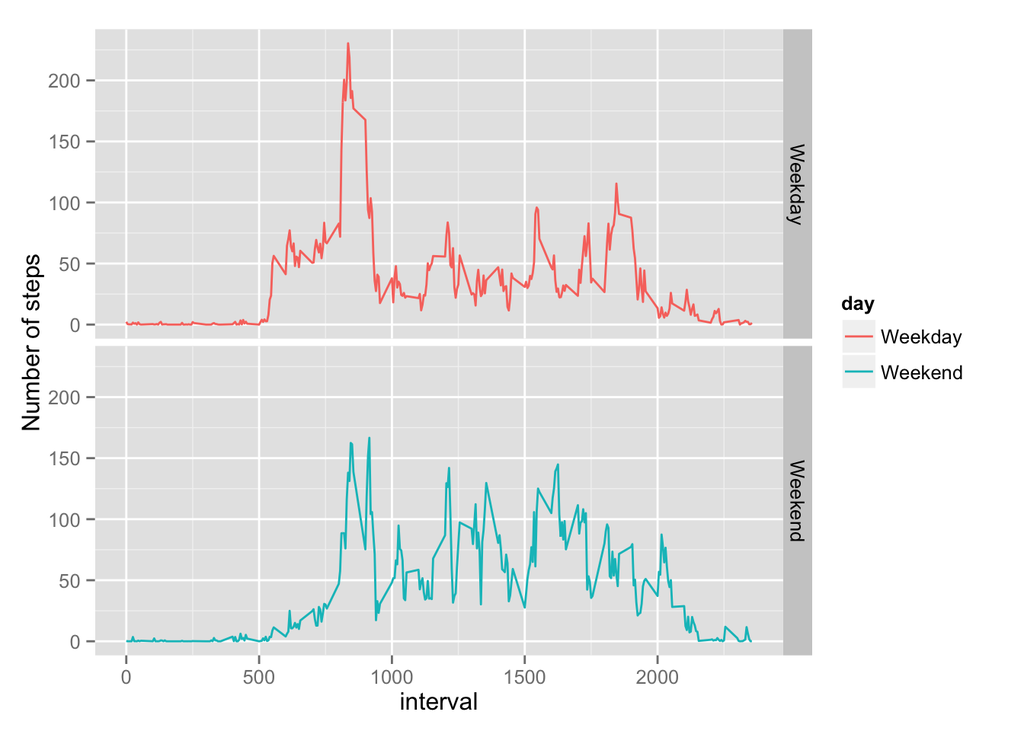

```r
aggmergedData_day <- aggregate(steps.x~interval+day,mergedData,mean)
g <- ggplot(aggmergedData_day,aes(interval,steps.x,colour=day))
g + geom_line() + facet_grid(day~.) + labs(y="Number of steps")
```